# 20251101_Baseline_Outcome

Yu-Chun Huang, Chun-yu Shih

2025-11-04

# Background

- **Author**: `<Yu-Chun Huang, Chun-yu Shih>`
- **Created At**: `<2025-11-01>`
- **Research Motivation and Context (why are we interested in the findings?)**:  
  The animal center has to balance the welfare of animals and the efficiency of corporate operations. Analyzing and explaining the staying day of animals can help us design targeted intervention, like behavioral training and adoption matching activities.
- **Main Findings and Takeaways**： Using OLS model, we found that dogs are more easily adopted than cats. To determine the most important feature that causes the difference of days animal staying, we use the random forest model. Excluding the animals type, the most important feature is the animals color pattern. In our case, there are 417 different colors which may cause the lack of sample in each colors. Therefore, we simplify the different colors as the color pattern, like solid color, bicolor, more than 3 colors, and patterned. As the regression result, the solid color animals are the most easily to be adopted and the tricolor are the most difficult. The last result makes us surprisingly, the intact animals are more easily adopted than the sterilized animals.
- **Future Direciton**： Using survival analysis to estimate the timing of adoption dynamically. Analyzing the data type of sterilized, less than 4% animals are intact animals. It may cause the biased significantly, the solution we thought is using the imbalanced learning method on our sterilized data.

```r
library(readxl)
library(tidyverse)
library(janitor)
library(lubridate)
library(lmtest)
library(ranger)
library(broom)
library(gt)
library(glue)
library(ggplot2)
library(dplyr)
library(tidyr)
library(purrr)
library(ggrepel)
```

```r
# import data
austin <- read.csv("/Users/nnychhi/Desktop/碩二/austin.csv")

# data clean up
austin_clear <- austin %>%
  # drop irrelevant variable
  select(-c("Name", "Found.Location", "Sex.upon.Intake", "Age.upon.Intake",
            "Date.of.Birth", "Outcome.Subtype", "Age.upon.Outcome")) %>%
  # rename in lower case
  rename_with(tolower) %>%
  # filter for animal and outcome type
  filter(animal.type %in% c("Cat", "Dog"), outcome.type == "Adoption") %>%
  mutate(animal.type = factor(animal.type, levels = c("Dog", "Cat"))) %>% # 0: dog
  # standardized name form
  rename(intake.datetime = intake_datetime,
         outcome.datetime = outcome_datetime) %>%
  # calculate duration of stay
  mutate(start.date = ymd_hms(intake.datetime),
         end.date = ymd_hms(outcome.datetime),
         stay.day.round = round(as.numeric(difftime(end.date, start.date, units = "days")), 2),
         stay.day = floor(as.numeric(difftime(end.date, start.date, units = "days")))) %>%
  # adjustment
  select(-c("outcome.type", "start.date", "end.date"))%>%
  # variable redefined: sex_upon_outcome
  mutate(
    sterilized = case_when(
      grepl("Neutered|Spayed", sex.upon.outcome, ignore.case = TRUE) ~ "Sterilized",
      grepl("Intact", sex.upon.outcome, ignore.case = TRUE) ~ "Intact",
      TRUE ~ "Unknown",
    ),
    sex = case_when(
      sex.upon.outcome == "Unknown" ~ "Unknown",
      TRUE ~ str_to_title(word(sex.upon.outcome, -1))  # pick last word：Male / Female
    ),
    sterilized = factor(sterilized, levels = c("Intact", "Sterilized", "Unknown")), # 0:未絕育
    sex = factor(sex, levels = c("Male", "Female", "Unknown")) # 0: 雄性
  ) %>%
  select(-sex.upon.outcome) %>%
  # variable redefined: breed
  mutate(is_mixed = if_else(str_detect(breed, "Mix|/|-|&"), "Mixed", "Purebred"),
         is_mixed = factor(is_mixed, levels = c("Purebred", "Mixed")) # 0: 純種
         ) %>%
  # variable redefined: color
  mutate(
    color_type = case_when(
      str_detect(color, "(?i)Tabby|Brindle|Tortie|Calico|Merle|Point|Tick|Spotted|Speckled") ~ "Patterned",
      str_count(color, "/|&| ") == 0 ~ "Solid",
      str_count(color, "/|&| ") == 1 ~ "Bicolor",
      str_count(color, "/|&| ") >= 2 ~ "Tricolor+",
      TRUE ~ "Unknown"
    ),
    color_type = factor(color_type, levels = c("Solid", "Bicolor", "Tricolor+", "Patterned")) # 0: 純色
  ) %>%
  # adjust variable name form
  rename_with(~ str_replace_all(.x, "\\.", "_"))

# further selection for analysis
# (austin_clear remains some vars for future analysis)
austin_for_analysis <- austin_clear %>%
  select(-c("intake_datetime", "intake_type", "intake_condition", "stay_day",
            "breed", "color", "outcome_datetime")) %>%
  mutate(log_stay_day_round = log1p(stay_day_round)) %>%
  # drop incomplete observations
  filter(
    if_all(
      c(sex, sterilized, color_type),
      ~ . != "Unknown" & !is.na(.)
    )
  )
# print first 10 obs
head(austin_for_analysis, 10)
```

```
##    animal_id animal_type stay_day_round sterilized    sex is_mixed color_type
## 1    A735087         Dog           4.07 Sterilized Female    Mixed    Bicolor
## 2    A797186         Cat          28.13 Sterilized Female Purebred  Patterned
## 3    A797012         Cat          42.28 Sterilized Female    Mixed  Patterned
## 4    A797012         Cat          26.85 Sterilized Female    Mixed  Patterned
## 5    A730005         Cat          59.03 Sterilized Female    Mixed      Solid
## 6    A673736         Dog           0.05     Intact   Male    Mixed      Solid
## 7    A694324         Dog          12.82 Sterilized Female    Mixed      Solid
## 8    A827193         Cat          19.89 Sterilized Female Purebred  Patterned
## 9    A733404         Cat          20.88 Sterilized Female    Mixed  Patterned
## 10   A815044         Dog           4.78 Sterilized Female    Mixed      Solid
##    log_stay_day_round
## 1          1.62334082
## 2          3.37176857
## 3          3.76769063
## 4          3.32683297
## 5          4.09484444
## 6          0.04879016
## 7          2.62611682
## 8          3.03927058
## 9          3.08557298
## 10         1.75440368
```

```r
# Before conducting the analysis, report summary statistics for all variables
# that will be used in this notebook:
#   - For numeric variables: mean, min, 25th percentile, median, 75th percentile,
#     max, standard deviation, and number of observations.
#   - For categorical variables: number of observations and the counts/percentages
#     of the ten most frequent categories.
# Conclude this block with the complete summary statistics.

# Classified to numeric and character data
num_vars <- austin_clear |> select(where(is.numeric))
cat_vars <- austin_clear |> select(where(is.factor) | where(is.character))

# Summary statistics of numeric data
num_summary <- num_vars |>
  gather(variable, value) |>
  group_by(variable) |>
  summarise(
    Obs. = sum(!is.na(value)),
    Mean = mean(value, na.rm = TRUE),
    S.D. = sd(value, na.rm = TRUE),
    Min = min(value, na.rm = TRUE),
    Q1 = quantile(value, 0.25, na.rm = TRUE),
    Median = median(value, na.rm = TRUE),
    Q3 = quantile(value, 0.75, na.rm = TRUE),
    Max = max(value, na.rm = TRUE)
  )
cat("Numeric Variables Summary\n")
```

```
## Numeric Variables Summary
```

```r
print(num_summary)
```

```
## # A tibble: 2 × 9
##   variable        Obs.  Mean  S.D.   Min    Q1 Median    Q3   Max
##   <chr>          <int> <dbl> <dbl> <dbl> <dbl>  <dbl> <dbl> <dbl>
## 1 stay_day       53983  32.3  57.6     0  5      11    40   1521
## 2 stay_day_round 53983  32.7  57.6     0  5.05   11.3  40.8 1522.
```

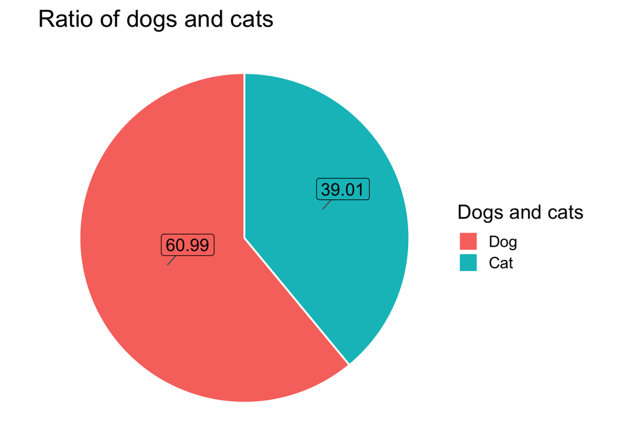

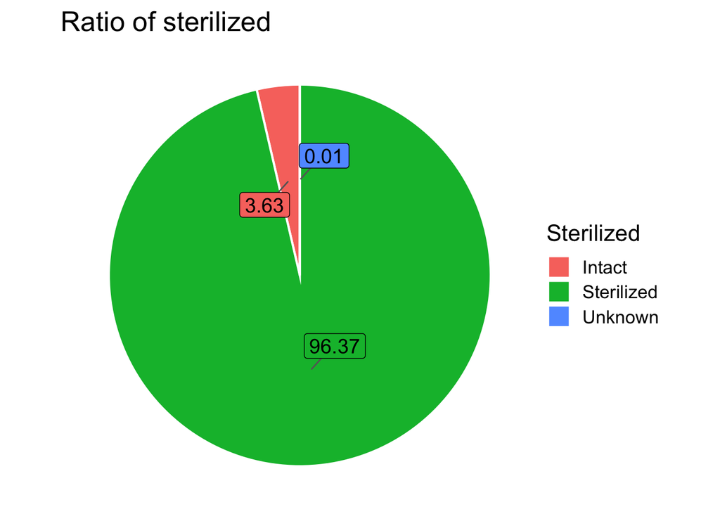

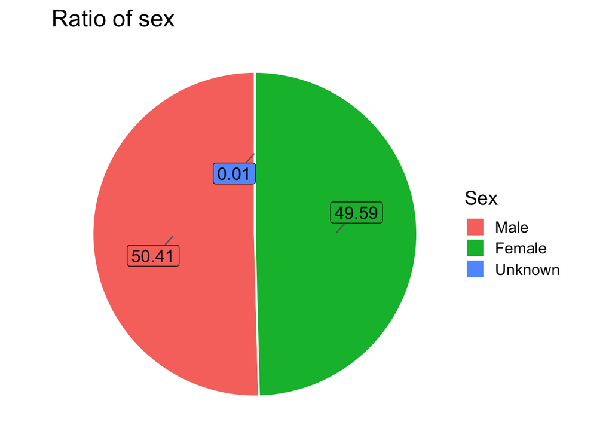

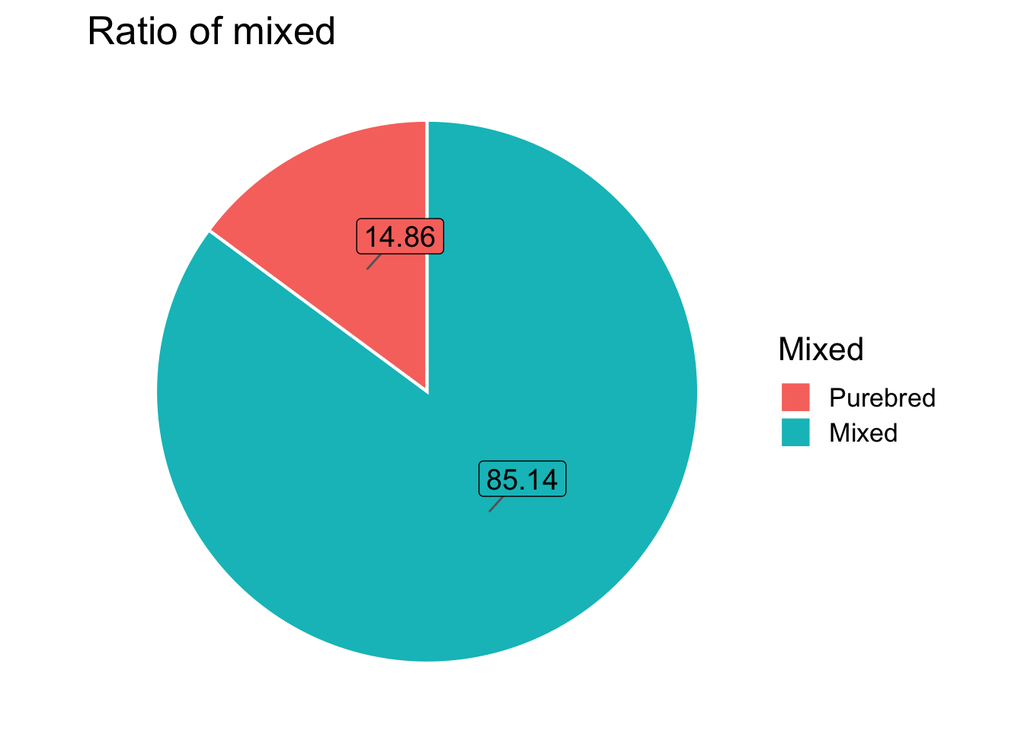

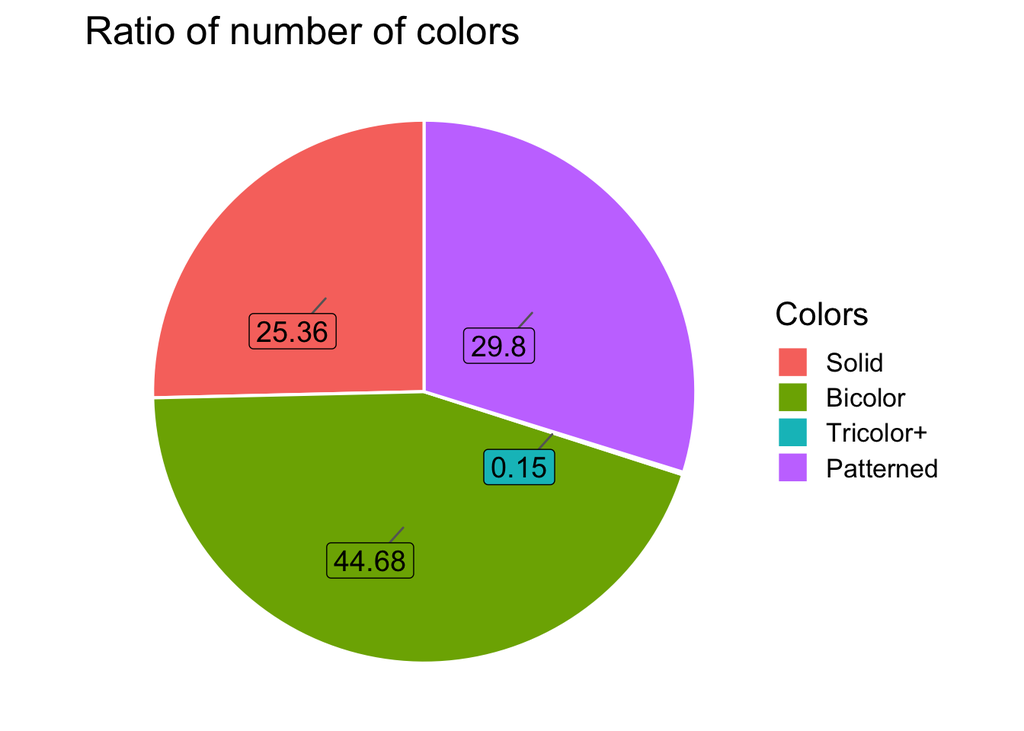

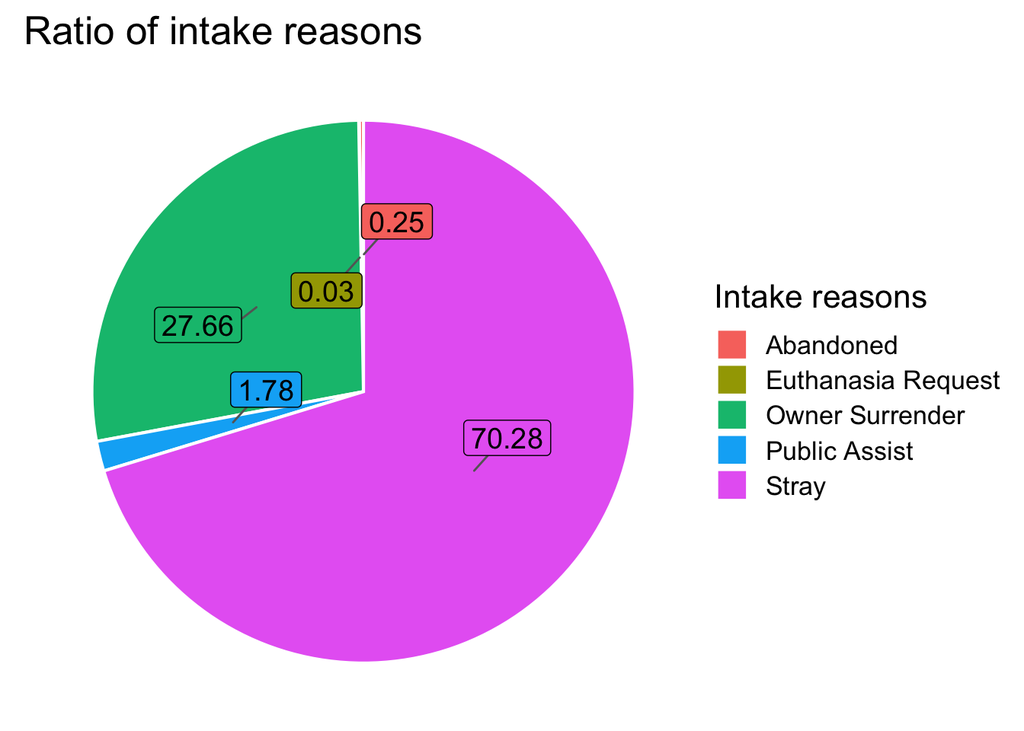

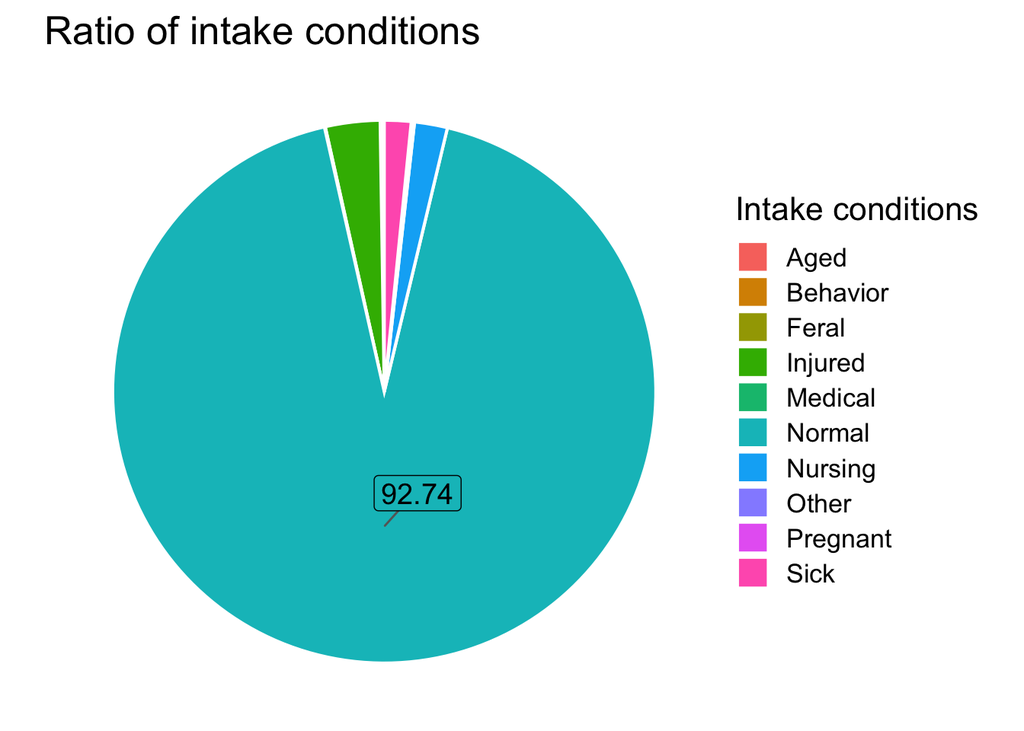

```r
# Setting the title of categorical data
title_map <- c(
  animal_type = "Ratio of dogs and cats",
  sterilized = "Ratio of sterilized",
  sex = "Ratio of sex",
  is_mixed = "Ratio of mixed",
  color_type = "Ratio of number of colors",
  intake_type = "Ratio of intake reasons",
  intake_condition = "Ratio of intake conditions"
)
x_map <- c(
  animal_type = "Dogs and cats",
  sterilized = "Sterilized",
  sex = "Sex",
  is_mixed = "Mixed",
  color_type = "Colors",
  intake_type = "Intake reasons",
  intake_condition = "Intake conditions"
)
# Summary statistics of categorical data
max_unique <- 10
cat_vars <- austin_clear %>% select(where(is.factor) | where(is.character))
map(names(cat_vars), function(v) {
  n_levels <- n_distinct(austin_clear[[v]])
  if (n_levels <= max_unique) {
    sumstat <- austin_clear %>%
      count(!!sym(v)) %>%
      mutate(percentage = round(100 * n / sum(n), 2),
             label = sprintf("%s (%.1f%%)", v, percentage))

    p <- ggplot(sumstat, aes(x = "", y = percentage, fill = !!sym(v))) +
      geom_col(width = 0.5, color = "white") +
      coord_polar(theta = "y") +
      geom_label_repel(aes(label = percentage),
                   position = position_stack(vjust = 0.5),
                   size = 5, show.legend = FALSE,
                   box.padding = 0.5, segment.color = "gray40") +
  theme_void(base_size = 16) +
  labs(title = title_map[[v]], fill = x_map[[v]])
  }
})
```

### The actual analysis starts below

#### OLS estimation

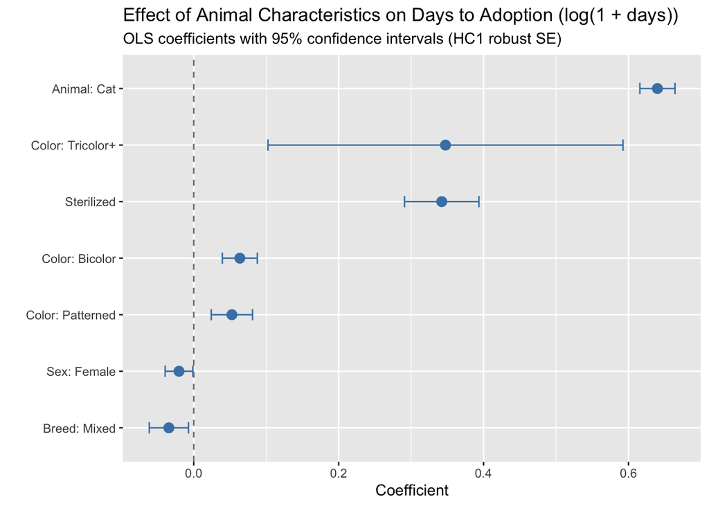

```r
# baseline analysis: OLS + RF
## OLS ---
lm_baseline <- lm(log_stay_day_round ~ animal_type + sterilized + sex + is_mixed
                  + color_type, data = austin_for_analysis)

lm_baseline_summary <- tidy(lm_baseline, conf.int = TRUE)

vc_hc1_lm_baseline <- sandwich::vcovHC(lm_baseline, type = "HC1")
tidy_hc1 <- broom::tidy(lm_baseline, conf.int = TRUE, vcov = vc_hc1_lm_baseline)

# star for estimated coefficients
star <- function(p){
  ifelse(p < 0.01, "***",
         ifelse(p < 0.05, "**",
                ifelse(p < 0.10, "*", "")))
}

# plot: estimated coefficient
coef_plot <- tidy_hc1 %>%
  filter(term != "(Intercept)") %>%
  mutate(term = recode(term,
                       "animal_typeCat" = "Animal: Cat",
                       "sterilizedSterilized" = "Sterilized",
                       "sexFemale" = "Sex: Female",
                       "is_mixedMixed" = "Breed: Mixed",
                       "color_typeBicolor" = "Color: Bicolor",
                       "color_typeTricolor+" = "Color: Tricolor+",
                       "color_typePatterned" = "Color: Patterned"
  ))

ggplot(coef_plot, aes(x = reorder(term, estimate), y = estimate)) +
  geom_point(size=3, color="steelblue") +
  geom_errorbar(aes(ymin = conf.low, ymax = conf.high), width = 0.2, color="steelblue") +
  geom_hline(yintercept = 0, linetype="dashed", color="gray50") +
  coord_flip() +
  labs(
    title = "Effect of Animal Characteristics on Days to Adoption (log(1 + days))",
    subtitle = "OLS coefficients with 95% confidence intervals (HC1 robust SE)",
    x = "",
    y = "Coefficient"
  )
```

Our base group is the purebred male dog with solid color which has not sterilized yet. We use 95% confidence interval with heteroskedasticity assumption. As a result, almost all of variables have statistically significant explanation.

```r
# result table preparation
tbl_coef <- tidy_hc1 %>%
  filter(term != "(Intercept)") %>%
  mutate(
    term = recode(term,
                  "animal_typeCat"     = "Animal: Cat",
                  "sterilizedSterilized" = "Sterilized",
                  "sexFemale"          = "Sex: Female",
                  "is_mixedMixed"      = "Breed: Mixed",
                  "color_typeBicolor"  = "Color: Bicolor",
                  "color_typeTricolor+"= "Color: Tricolor+",
                  "color_typePatterned"= "Color: Patterned"
    ),
    sig  = star(p.value),
    est_with_star = ifelse(sig=="",
                           sprintf("%.3f", estimate),
                           sprintf("%.3f<sup>%s</sup>", estimate, sig)),
    ci_col = sprintf("[%.3f, %.3f]", conf.low, conf.high)
  ) %>%
  transmute(
    Term = term,
    Estimate = est_with_star,
    `Std. Error (HC1)` = sprintf("%.3f", std.error),
    `95% CI` = ci_col,
    `p-value` = sprintf("%.3f", p.value)
  )

# add outcome variable mean, r square
g_stats <- glance(lm_baseline)
y_mean  <- mean(austin_for_analysis$log_stay_day_round, na.rm = TRUE)

# result table
result_tbl <- tbl_coef %>%
  gt() %>%
  tab_header(
    title = md("**OLS results with HC1 robust standard errors**"),
    subtitle = md(glue("Outcome mean (log(1 + days)) = **{sprintf('%.3f', y_mean)}**"))
  ) %>%
  fmt_markdown(columns = "Estimate") %>%
  cols_label(
    Term = "Variable",
    Estimate = "Estimate",
    `Std. Error (HC1)` = "Std. Error (HC1)",
    `95% CI` = "95% CI",
    `p-value` = "p-value"
  ) %>%
  cols_align(
    align = "left",
    columns = vars(Term)
  ) %>%
  cols_align(
    align = "right",
    columns = c("Estimate", "Std. Error (HC1)", "95% CI", "p-value")
  ) %>%
  tab_source_note(
    source_note = md(
      glue("**R²** = {sprintf('%.3f', g_stats$r.squared)}; ",
           "**Adj. R²** = {sprintf('%.3f', g_stats$adj.r.squared)}; ",
           "**N** = {g_stats$nobs}")
    )
  ) %>%
  tab_source_note(
    source_note = md(
      "**Base groups:** Animal = Dog; Sterilization = Intact; Sex = Male; Breed = Purebred; Color = Solid."
    )
  ) %>%
  tab_style(
    style = list(
      cell_text(size = "smaller", color = "gray40", align = "left")
    ),
    locations = cells_source_notes()
  ) %>%
  opt_row_striping()

result_tbl
```

**OLS results with HC1 robust standard errors**

Outcome mean (log(1 + days)) = **2.771**

| Variable | Estimate | Std. Error (HC1) | 95% CI | p-value |
| --- | --- | --- | --- | --- |
| Animal: Cat | 0.640*** | 0.012 | [0.616, 0.664] | 0.000 |
| Sterilized | 0.342*** | 0.026 | [0.291, 0.394] | 0.000 |
| Sex: Female | -0.020** | 0.010 | [-0.040, -0.001] | 0.038 |
| Breed: Mixed | -0.034** | 0.014 | [-0.061, -0.007] | 0.013 |
| Color: Bicolor | 0.064*** | 0.012 | [0.039, 0.088] | 0.000 |
| Color: Tricolor+ | 0.347*** | 0.125 | [0.102, 0.592] | 0.005 |
| Color: Patterned | 0.053*** | 0.015 | [0.024, 0.081] | 0.000 |

**R²** = 0.072; **Adj. R²** = 0.072; **N** = 53980  
**Base groups:** Animal = Dog; Sterilization = Intact; Sex = Male; Breed = Purebred; Color = Solid.

Although all of variables have statistically significant, the sex and breed of animals have weaker explanation than others. Because the explained variable y is the logarithm of staying day, the positive coefficient means the higher value of X the longer days animal staying. Therefore, the staying day of cats is longer than dogs about 89% (e^0.640 - 1), the other variable are the same way to analyze.

#### Random forest estimation

We apply random forest model to estimate the importance of each variables, and the result can be compared with the result of OLS.

To conduct random forest estimation. First, we find the best number of covariates randomly selected at each split. (denoted by m in the lecture note)

```r
## RF ---
set.seed(5166)

# find the best m (number of covariates randomly selected at each split)
p <- 5
mtry_values <- 1:p

m_results <- data.frame(mtry = mtry_values, OOB_MSE = NA)

 # test for different m
for (i in seq_along(mtry_values)) {
  rf_temp <- ranger(
    log_stay_day_round ~ animal_type + sterilized + sex + is_mixed + color_type,
    data = austin_for_analysis,
    num.trees = 500,
    mtry = mtry_values[i],
    importance = "impurity"
  )
  m_results$OOB_MSE[i] <- rf_temp$prediction.error
}

 # best m: 3
print(m_results)
```

```
##   mtry  OOB_MSE
## 1    1 1.300652
## 2    2 1.281513
## 3    3 1.280294
## 4    4 1.280499
## 5    5 1.280648
```

```r
#best_mtry <- m_results$mtry[which.min(m_results$OOB_MSE)]
#cat("Best mtry =", best_mtry, "\n")
```

We can see that the OOB_MSE is lowest when m = 3.

So we then conduct random forest and set m = 3. The result shows below:

```r
# RF model
rf_baseline <- ranger(
  log_stay_day_round ~ animal_type + sterilized + sex + is_mixed + color_type,
  data = austin_for_analysis,
  num.trees = 500,
  mtry = 3,
  importance = "permutation"
  # use permutation since we focus on importance
)

rf_baseline$variable.importance
```

```
## animal_type  sterilized         sex    is_mixed  color_type
## 0.194682214 0.009806775 0.002249530 0.004918372 0.015508116
```

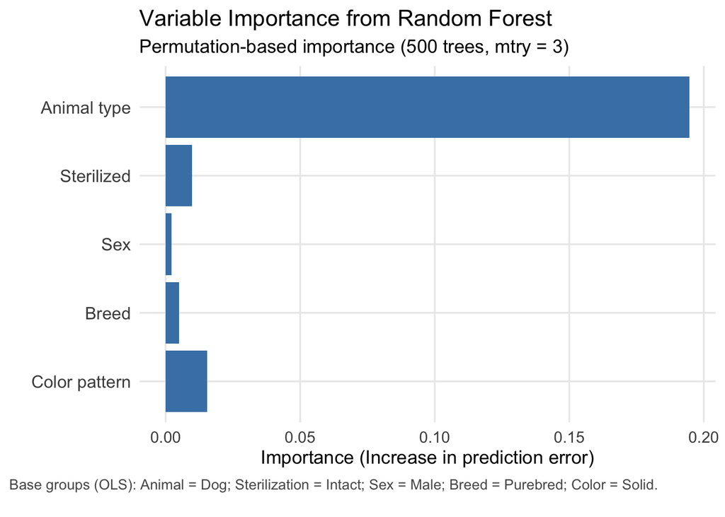

```r
# rf importance plot
rf_importance <- as.data.frame(rf_baseline$variable.importance) %>%
  rownames_to_column("Variable") %>%
  rename(Importance = 2)

# adjust variable names
as_ols_names <- c(
  animal_type = "Animal type",
  sterilized  = "Sterilized",
  sex         = "Sex",
  is_mixed    = "Breed",
  color_type  = "Color pattern"
)

display_order <- c("Animal type","Sterilized","Sex","Breed","Color pattern")

rf_importance <- rf_importance %>%
  mutate(
    Variable = recode(Variable, !!!as_ols_names),
    Variable = factor(Variable, levels = rev(display_order))
  )

ggplot(rf_importance, aes(x = Variable, y = Importance)) +
  geom_col(fill = "steelblue") +
  coord_flip() +
  labs(
    title    = "Variable Importance from Random Forest",
    subtitle = "Permutation-based importance (500 trees, mtry = 3)",
    x = "",
    y = "Importance (Increase in prediction error)",
    caption = paste(
      "Base groups (OLS): Animal = Dog; Sterilization = Intact; Sex = Male;",
      "Breed = Purebred; Color = Solid.\n"
    )
  ) +
  theme_minimal(base_size = 13) +
  theme(
    plot.caption = element_text(
      hjust = 0, color = "gray35", size = 10,
      margin = ggplot2::margin(t = 8, unit = "pt")
    ),
    plot.caption.position = "plot",
    axis.text.y  = element_text(size = 12),
    axis.text.x  = element_text(size = 11),
    panel.grid.minor = element_blank()
  )
```

The result of random forest tells us “animal type” and “color pattern” are 2 variables that have most importance on the log stay days.